# Métodos multivariados - Parcial 1

Elmer Calel - 201213600

18/4/2020

```r
# Librerías necesarias

library(readr)
library(cluster)
library(factoextra)
library(tidyverse)
```

## Problema 1

Descargue el archivo **ingreso**, en el cual se encuentra la información de el ingreso promedio para diferentes profesiones en los Estados Unidos desde el año 2001 hasta 2016.

```r
ingreso <- read_csv("../Data/ingreso.csv")
ingreso.matrix <- as.matrix(ingreso[,2:16])
rownames(ingreso.matrix) <-  as.matrix(ingreso[,1])

# Matriz de datos
ingreso.matrix
```

```
##                             2001  2002  2003  2004  2005  2006  2007   2008
## Management                 70800 78870 83400 87090 88450 91930 96150 100310
## Business Operations        50580 53350 56000 57120 57930 60000 62410  64720
## Computer Science           60350 61630 64150 66370 67100 69240 72190  74500
## Architecture/Engineering   56330 58020 60390 63060 63910 66190 68880  71430
## Life/Physical/Social Sci.  49710 52380 54930 57550 58030 59660 62020  64280
## Community Services         34190 34630 35800 37050 37530 39000 40540  41790
## Legal                      69030 77330 78590 81180 81070 85360 88450  92270
## Education/Training/Library 39130 40160 41390 42810 43450 45320 46610  48460
## Arts/Design/Entertainment  39770 41660 43350 43820 44310 46110 48410  50670
## Healthcare Practitioners   49930 53990 56240 58310 59170 62030 65020  67890
## Healthcare Support         21900 22410 22960 23510 23850 24610 25600  26340
## Protective Service         32530 33330 34430 35240 35750 37040 38750  40200
## Food Preparation           16720 17180 17400 17620 17840 18430 19440  20220
## Grounds Cleaning & Maint.  20380 20850 21290 21670 21930 22580 23560  24370
## Personal Care              21010 21370 21570 22080 22180 22920 23980  24120
## Sales                      28920 30610 31560 32280 32800 34350 35240  36080
## Office Administrative      27230 27910 28540 29390 29710 30370 31200  32220
## Farming/Fishing/Forestry   19630 20220 20290 20670 21010 21810 22640  23560
## Construction               35450 36340 37000 37890 38260 39290 40620  42350
## Installation/Repair/Maint. 34960 35780 36560 37620 38050 39060 39930  41230
## Production                 27600 28190 28930 29480 29890 30480 31310  32320
## Transportation/Moving      26560 27220 27630 28250 28820 29460 30680  31450
##                              2010   2011   2012   2013   2014   2015   2016
## Management                 105440 107410 108570 110550 112490 115020 118020
## Business Operations         67690  68740  69550  71020  72410  73800  75070
## Computer Science            77230  78730  80180  82010  83970  86170  87880
## Architecture/Engineering    75550  77120  79000  80100  81520  82980  84300
## Life/Physical/Social Sci.   66390  67470  68360  69400  70070  71220  72930
## Community Services          43180  43830  44240  44710  45310  46160  47200
## Legal                       96940  98380  98570  99620 101110 103460 105980
## Education/Training/Library  50440  50870  51210  51500  52210  53000  54520
## Arts/Design/Entertainment   52290  53850  54490  55580  55790  56980  58390
## Healthcare Practitioners    71280  72730  73540  74740  76010  77800  79160
## Healthcare Support          26920  27370  27780  28300  28820  29520  30470
## Protective Service          42490  42730  43050  43510  43980  44610  45810
## Food Preparation            21240  21430  21380  21580  21980  22850  23850
## Grounds Cleaning & Maint.   25300  25560  25670  26010  26370  27080  28010
## Personal Care               24590  24620  24550  24710  24980  25650  26510
## Sales                       36790  37520  37990  38200  38660  39320  40560
## Office Administrative       33470  34120  34410  34900  35530  36330  37260
## Farming/Fishing/Forestry    24330  24300  24230  24330  25160  26360  27810
## Construction                43870  44630  44960  45630  46600  47580  48900
## Installation/Repair/Maint.  42810  43390  43870  44420  45220  45990  46690
## Production                  33770  34220  34500  34930  35490  36220  37190
## Transportation/Moving       32660  33200  33590  33860  34460  35160  36070
```

Se desea realizar un análisis de Cluster con este conjunto de datos. (necesitara modificar el data frame para quitar las variables que no sean numéricas)

- Calcule la matriz de distancia euclidiana.

```r
ingreso.distancia <- dist(ingreso.matrix, method = "euclidean")

# Matriz de distancia euclidiana
ingreso.distancia
```

```
##                             Management Business Operations Computer Science
## Business Operations        134984.8906
## Computer Science            95969.7869          39396.6356
## Architecture/Engineering   106436.3444          28750.6330       11558.3649
## Life/Physical/Social Sci.  139429.8569           5249.1809       43894.4666
## Community Services         225035.6150          90112.8964      129413.6152
## Legal                       32657.0819         103311.9262       64250.3105
## Education/Training/Library 200195.8796          65266.9526      104566.1905
## Arts/Design/Entertainment  190772.1193          55890.0009       95218.6206
## Healthcare Practitioners   124488.0332          11361.3424       29702.6867
## Healthcare Support         283316.3557         148446.5099      187746.4849
## Protective Service         230482.2147          95591.9505      134913.5164
## Food Preparation           306846.1390         172017.4389      211324.4127
## Grounds Cleaning & Maint.  291049.1568         156183.6758      195489.0690
## Personal Care              292984.4890         158077.3453      197368.8856
## Sales                      247016.7759         112116.2687      151425.2073
## Office Administrative      259499.1644         124590.5221      163885.0545
## Farming/Fishing/Forestry   294737.3870         159881.6825      199177.6898
## Construction               221416.4030          86467.3464      125744.4245
## Installation/Repair/Maint. 225228.2371          90268.8058      129540.2169
## Production                 259080.8376         124160.8920      163454.1361
## Transportation/Moving      263007.8115         128102.5855      167400.4155
##                            Architecture/Engineering Life/Physical/Social Sci.
## Business Operations
## Computer Science
## Architecture/Engineering
## Life/Physical/Social Sci.                33385.7425
## Community Services                      118723.9774                85723.0086
## Legal                                    74964.9345               107689.7340
## Education/Training/Library               93905.1010                60845.6046
## Arts/Design/Entertainment                84460.8744                51618.0947
## Healthcare Practitioners                 18543.1551                16068.7087
## Healthcare Support                      177026.1822               144083.9193
## Protective Service                      124175.6937                91235.3194
## Food Preparation                        200575.3464               167669.3270
## Grounds Cleaning & Maint.               184761.6348               151820.0590
## Personal Care                           186692.8504               153673.8820
## Sales                                   140742.2247               107709.7888
## Office Administrative                   153187.8948               120219.2393
## Farming/Fishing/Forestry                188460.0799               155524.0756
```

[output cut: 143 more lines]

```
## Education/Training/Library
## Arts/Design/Entertainment
## Healthcare Practitioners
## Healthcare Support
## Protective Service
## Food Preparation
## Grounds Cleaning & Maint.
## Personal Care
## Sales
## Office Administrative
## Farming/Fishing/Forestry
## Construction
## Installation/Repair/Maint.    4156.6453
## Production                   37719.1397                 33973.4014
## Transportation/Moving        41673.1664                 37945.2329   4030.9924
```

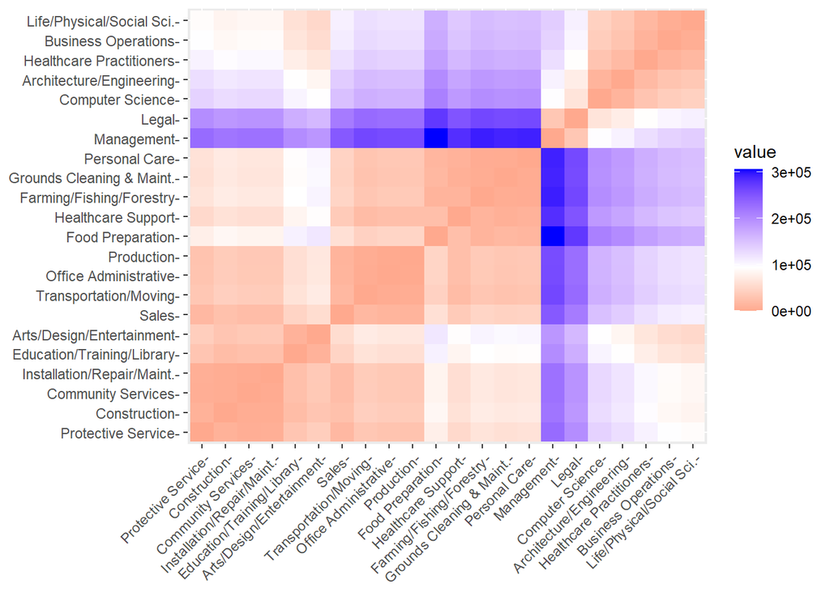

```r
# Gráfica de matriz de distancia
fviz_dist(dist.obj = ingreso.distancia)
```

- Genere una análisis de cluster con el método average.

```r
ingreso.cluster <-hclust(ingreso.distancia, method = "average")
ingreso.cluster
```

```
##
## Call:
## hclust(d = ingreso.distancia, method = "average")
##
## Cluster method   : average
## Distance         : euclidean
## Number of objects: 22
```

- Dibuje un dendograma de este análisis.

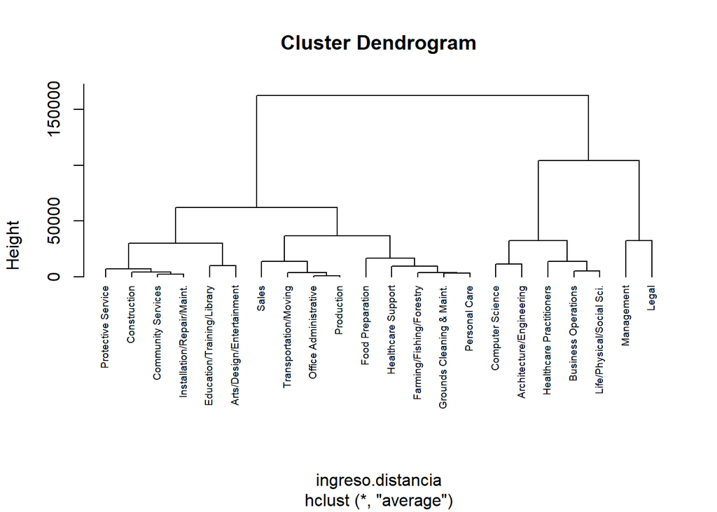

```r
plot(ingreso.cluster, hang = -0.01, cex = 0.6)
```

## Problema 2

Se necesita explorar los resultados anteriores (corte el dendograma con h=100,000), para ello necesitara crear un data frame con las siguientes columnas, **Ocupación, cluster, año, salario_promedio,** ejemplo:

| Ocupación | Cluster | Año | Salario_promedio |
| --- | --- | --- | --- |
| Computer Science | 2 | 2002 | 61630 |

Sugerencia( Agregue la columna cluster a su data frame original, después utilice la función gather de la librería tidyverse, para formar el data frame)

- Obtenga el dendograma diferenciando cada cluster con un color diferente.

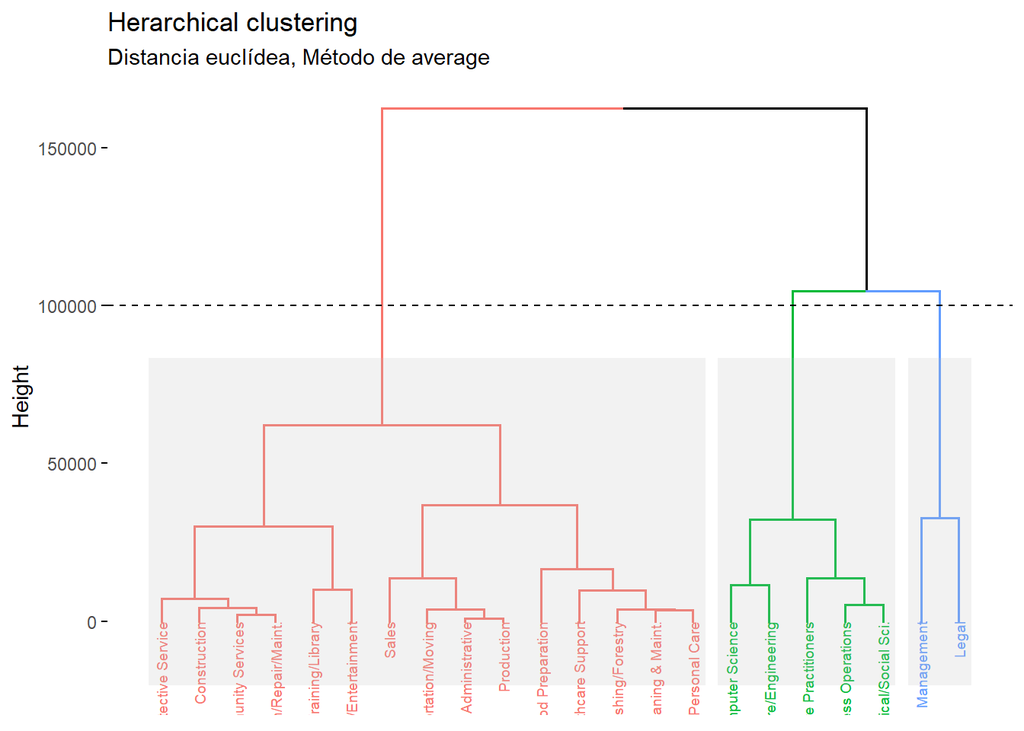

```r
fviz_dend(ingreso.cluster, k=3, cex= 0.5, color_labels_by_k = TRUE, rect = TRUE, rect_fill = T) +
  geom_hline(yintercept = 100000, linetype = "dashed") +
  labs(title = "Herarchical clustering",
       subtitle = "Distancia euclídea, Método de average")
```

- Dibuje un grafico de los individuos utilizando el método de componentes principales, diferenciando cada cluster con un color(utilice los comandos de factoextra).

```r
ajuste <- cutree(ingreso.cluster, k=3)
table(ajuste)
```

```
## ajuste
##  1  2  3
##  2  5 15
```

```r
print(rownames(ingreso.matrix)[ajuste==1])
```

```
## [1] "Management" "Legal"
```

```r
print(rownames(ingreso.matrix)[ajuste==2])
```

```
## [1] "Business Operations"       "Computer Science"
## [3] "Architecture/Engineering"  "Life/Physical/Social Sci."
## [5] "Healthcare Practitioners"
```

```r
print(rownames(ingreso.matrix)[ajuste==3])
```

```
##  [1] "Community Services"         "Education/Training/Library"
##  [3] "Arts/Design/Entertainment"  "Healthcare Support"
##  [5] "Protective Service"         "Food Preparation"
##  [7] "Grounds Cleaning & Maint."  "Personal Care"
##  [9] "Sales"                      "Office Administrative"
## [11] "Farming/Fishing/Forestry"   "Construction"
## [13] "Installation/Repair/Maint." "Production"
## [15] "Transportation/Moving"
```

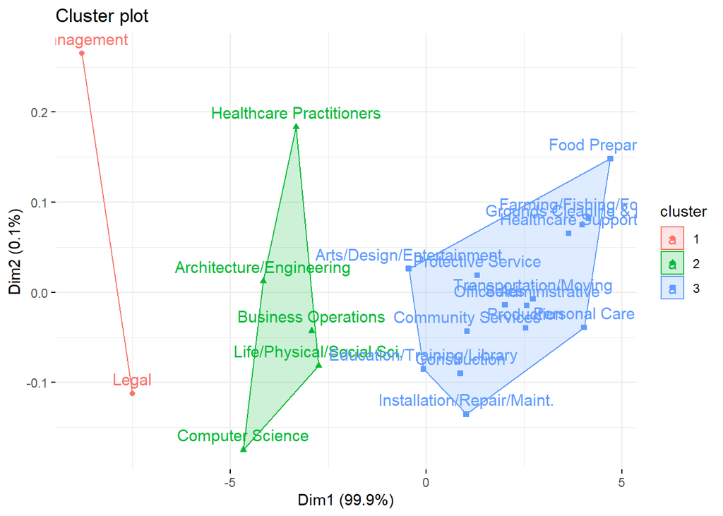

```r
fviz_cluster(list(data = ingreso.matrix, cluster = ajuste), ellipse.type = "convex",
             show.clust.cent = FALSE, ggtheme = theme_minimal())
```

Con los resultados anteriores se procede a crear el data fame solicitado.

```r
# Secre la función para crear el data frame y que será utilizada en e problema 4
df_analisis <- function(k, m, ajuste, df) {
  vector.ocupacion <- c()
  vector.cluster <- c()
  fila <- 1
  for (i in 1:k) {
    for (elemento in rownames(m)[ajuste==i]) {
      vector.ocupacion[fila] <- elemento
      vector.cluster[fila] <- i
      fila <- fila + 1
    }
  }

  df_clusters <- data.frame(vector.ocupacion, vector.cluster)
  names(df_clusters) <- c("X1", "Cluster")

  ingreso.clusters <- gather(left_join(df, df_clusters, by = "X1"), "Año", "Salario_promedio", 2:16)
  names(ingreso.clusters) <- c("Ocupacion", "Cluster", "Anio", "Salario_promedio")

  ingreso.clusters
}

ingreso.clusters <- df_analisis(3, ingreso.matrix, ajuste, ingreso)
ingreso.clusters
```

```
## # A tibble: 330 x 4
##    Ocupacion                  Cluster Anio  Salario_promedio
##    <chr>                        <int> <chr>            <dbl>
##  1 Management                       1 2001             70800
##  2 Business Operations              2 2001             50580
##  3 Computer Science                 2 2001             60350
##  4 Architecture/Engineering         2 2001             56330
##  5 Life/Physical/Social Sci.        2 2001             49710
##  6 Community Services               3 2001             34190
##  7 Legal                            1 2001             69030
##  8 Education/Training/Library       3 2001             39130
##  9 Arts/Design/Entertainment        3 2001             39770
## 10 Healthcare Practitioners         2 2001             49930
## # ... with 320 more rows
```

## Problema 3

Se desea conocer las tendencias de los salarios, utilizando el data frame obtenido en el inciso anterior, realice un grafico (curva) para explorar la relación de la variable año, con la variable salario, esto para cada cluster, utilice: **ggplot()+geom_line(aes(group(Ocupacion))).**

Deberá obtener algo parecido al siguiente grafico

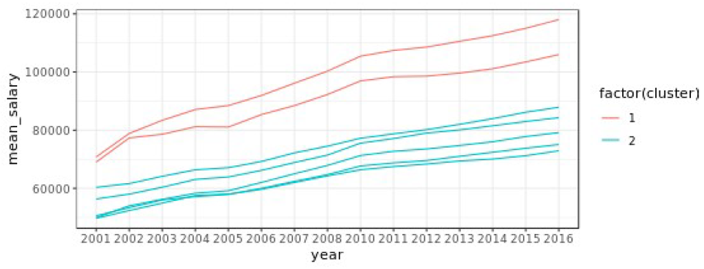

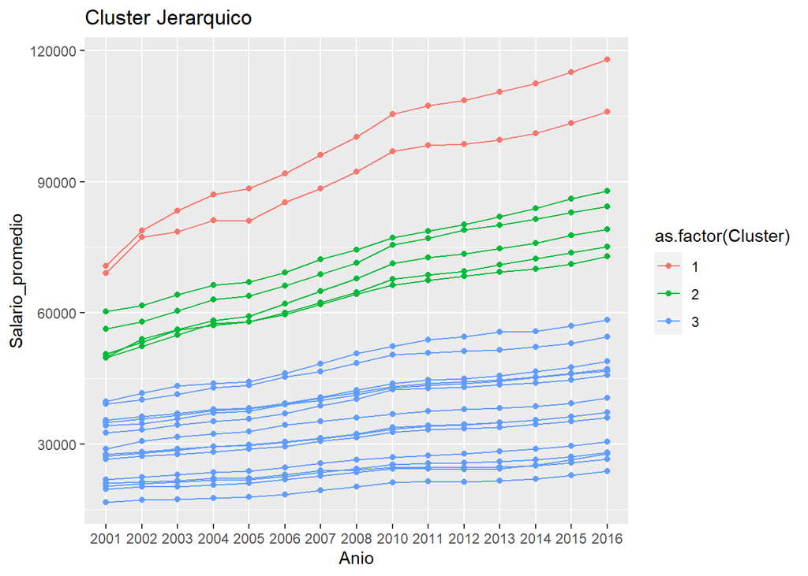

```r
ggplot(ingreso.clusters, aes(x=Anio, y=Salario_promedio, group=Ocupacion)) +
  geom_line(aes(color=as.factor(Cluster)))+
  geom_point(aes(color=as.factor(Cluster))) +
  labs(title="Cluster Jerarquico")
```

## Problema 4

Se desea analizar el mismo problema utilizando el algoritmo Kmeans.

- Utilice el criterio del codo para determinar un numero adecuado de k (grafique la suma de cuadrados).

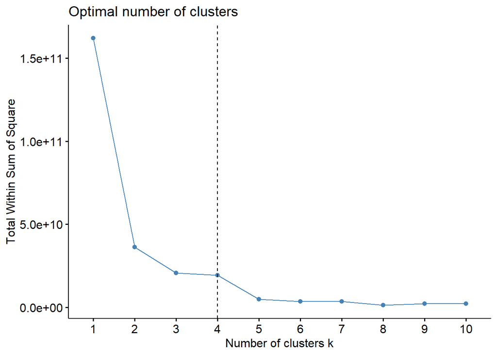

```r
set.seed(2)

ingreso.km <- kmeans(ingreso.matrix, centers = 1)$betweenss

for (i in 2:10) {
  ingreso.km[i] <- kmeans(ingreso.matrix, centers = i)$betweenss
}

fviz_nbclust(ingreso.matrix, kmeans, method = "wss") + geom_vline(xintercept = 4, linetype = 2)
```

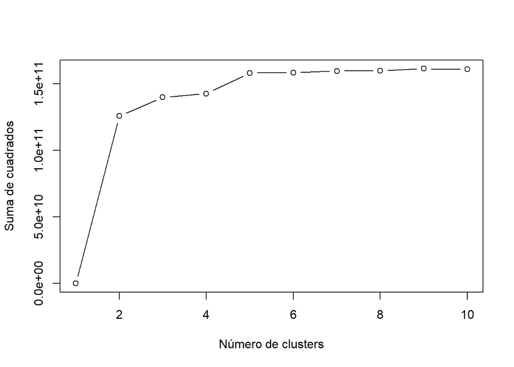

```r
plot(1:10, ingreso.km, type = "b", xlab = "Número de clusters", ylab = "Suma de cuadrados")
```

**De acuerdo a las gráficas anteriores, se concidera a k = 4 como un número óptimo.**

- Grafique con PCA y el método de kmeas, utilizando centers=2 y 7.

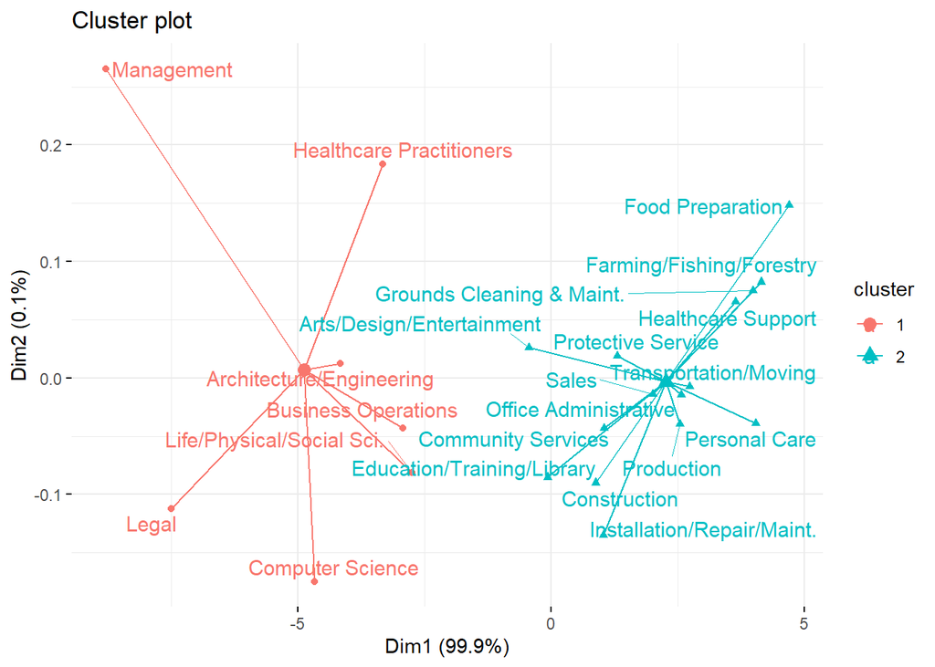

```r
ingreso.km2 <- kmeans(ingreso.matrix, nstart = 25, centers = 2)

fviz_cluster(ingreso.km2, data = ingreso.matrix, star.plot = TRUE, ellipse.type = "eclid", repel=T, ggtheme = theme_minimal())
```

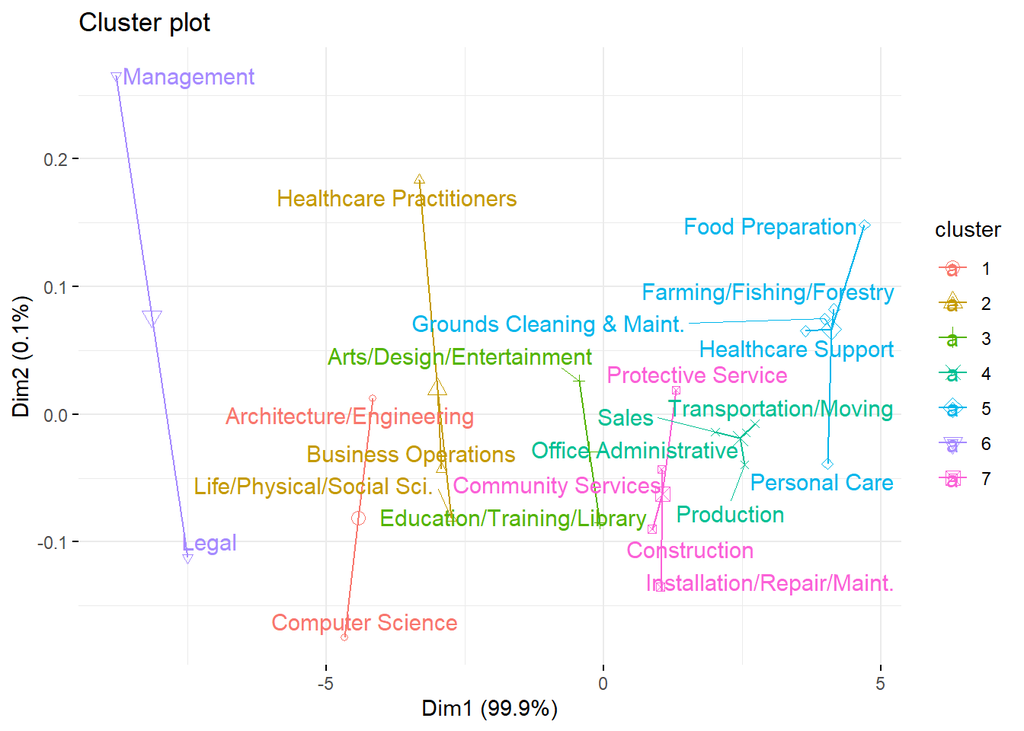

```r
ingreso.km7 <- kmeans(ingreso.matrix, nstart = 25, centers = 7)

fviz_cluster(ingreso.km7, data = ingreso.matrix, star.plot = TRUE, ellipse.type = "eclid", repel=T, ggtheme = theme_minimal())
```

- Realice el grafico de tendencia del problema 3 solo que con kmeans con centers=2 y centers=7.

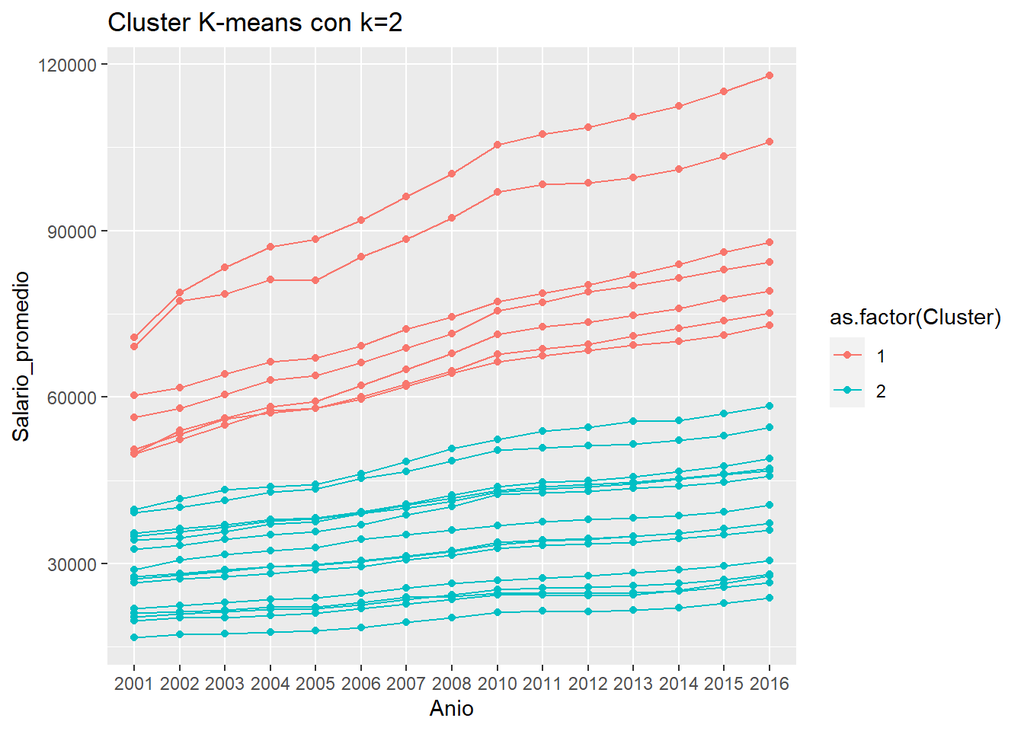

```r
ingreso.clusters <- df_analisis(2, ingreso.matrix, ingreso.km2$cluster, ingreso)

ggplot(ingreso.clusters, aes(x=Anio, y=Salario_promedio, group=Ocupacion)) +
  geom_line(aes(color=as.factor(Cluster)))+
  geom_point(aes(color=as.factor(Cluster))) +
  labs(title="Cluster K-means con k=2")
```

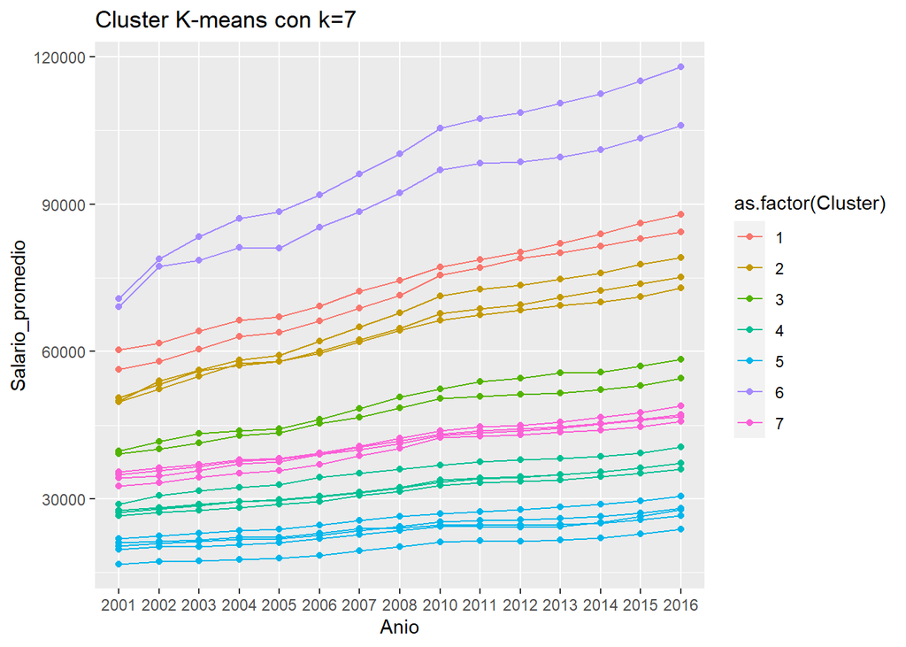

```r
ingreso.clusters <- df_analisis(7, ingreso.matrix, ingreso.km7$cluster, ingreso)

ggplot(ingreso.clusters, aes(x=Anio, y=Salario_promedio, group=Ocupacion)) +
  geom_line(aes(color=as.factor(Cluster)))+
  geom_point(aes(color=as.factor(Cluster))) +
  labs(title="Cluster K-means con k=7")
```

## Problema 5

En los problemas anteriores dibujo varios gráficos de tendencia, deberían ser los siguientes. De acuerdo a estas figuras.

¿Qué puede decir sobre la “mejor” forma de agrupar estos datos? (¿cual afirmación es correcta?)

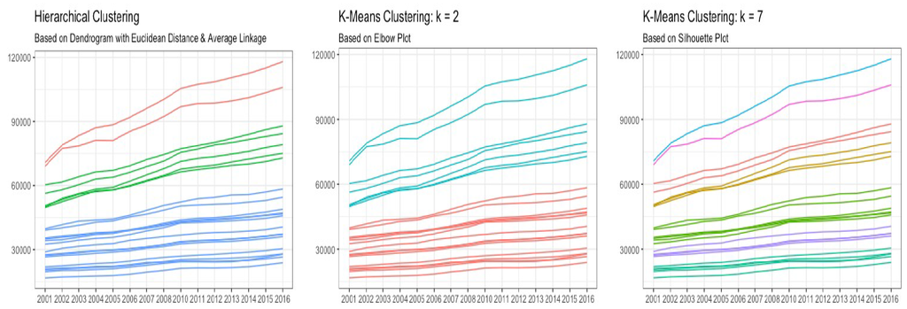

1. Todos los grupos generados por el grupo jerárquico tienen miembros con una distancia euclidiana entre ellos menor de 100,000 y, por lo tanto, es el mejor método de grupo.
2. Los grupos generados usando k-medias con k = 2 se identificaron mediante análisis de codo y, por lo tanto, es la mejor manera de agrupar estos datos.
3. Los grupos generados usando k-means con un k = 7 muestran una buena segmentación de los grupos en el grafico de tendencias.
4. Todo lo anterior es correcto, pero la mejor manera de agrupar depende en gran medida de cómo usaría estos datos después.

**La afirmación correcta sobre la mejor forma de agrupar los datos es la indicada en el inciso d**

*d. Todo lo anterior es correcto, pero la mejor manera de agrupar depende en gran medida de cómo usaría estos datos después.*

## Problema 6

si utiliza kmeans con k=7 obtenga:

- El promedio y desviación estándar del salario promedio para cada cluster en cada año

```r
ingreso.km7
```

```
## K-means clustering with 7 clusters of sizes 2, 3, 2, 4, 5, 2, 4
##
## Cluster means:
##       2001    2002     2003  2004     2005     2006    2007    2008      2010
## 1 58340.00 59825.0 62270.00 64715 65505.00 67715.00 70535.0 72965.0  76390.00
## 2 50073.33 53240.0 55723.33 57660 58376.67 60563.33 63150.0 65630.0  68453.33
## 3 39450.00 40910.0 42370.00 43315 43880.00 45715.00 47510.0 49565.0  51365.00
## 4 27577.50 28482.5 29165.00 29850 30305.00 31165.00 32107.5 33017.5  34172.50
## 5 19928.00 20406.0 20702.00 21110 21362.00 22070.00 23044.0 23722.0  24476.00
## 6 69915.00 78100.0 80995.00 84135 84760.00 88645.00 92300.0 96290.0 101190.00
## 7 34282.50 35020.0 35947.50 36950 37397.50 38597.50 39960.0 41392.5  43087.50
##        2011      2012     2013     2014      2015   2016
## 1  77925.00  79590.00  81055.0  82745.0  84575.00  86090
## 2  69646.67  70483.33  71720.0  72830.0  74273.33  75720
## 3  52360.00  52850.00  53540.0  54000.0  54990.00  56455
## 4  34765.00  35122.50  35472.5  36035.0  36757.50  37770
## 5  24656.00  24722.00  24986.0  25462.0  26292.00  27330
## 6 102895.00 103570.00 105085.0 106800.0 109240.00 112000
## 7  43645.00  44030.00  44567.5  45277.5  46085.00  47150
##
## Clustering vector:
##                 Management        Business Operations
##                          6                          2
##           Computer Science   Architecture/Engineering
##                          1                          1
##  Life/Physical/Social Sci.         Community Services
##                          2                          7
##                      Legal Education/Training/Library
##                          6                          3
##  Arts/Design/Entertainment   Healthcare Practitioners
##                          3                          2
##         Healthcare Support         Protective Service
##                          5                          7
##           Food Preparation  Grounds Cleaning & Maint.
##                          5                          5
##              Personal Care                      Sales
##                          5                          4
##      Office Administrative   Farming/Fishing/Forestry
##                          4                          5
##               Construction Installation/Repair/Maint.
##                          7                          7
##                 Production      Transportation/Moving
##                          4                          4
##
## Within cluster sum of squares by cluster:
## [1]  66797900 138279133  50175250 149679700 301792760 533242500  50327400
##  (between_SS / total_SS =  99.2 %)
##
## Available components:
##
## [1] "cluster"      "centers"      "totss"        "withinss"     "tot.withinss"
## [6] "betweenss"    "size"         "iter"         "ifault"
```

```r
# Promedio del salario promedio para cada cluster en cada año
aggregate(ingreso.matrix, by=list(cluster=ingreso.km7$cluster), mean)
```

```
##   cluster     2001    2002     2003  2004     2005     2006    2007    2008
## 1       1 58340.00 59825.0 62270.00 64715 65505.00 67715.00 70535.0 72965.0
## 2       2 50073.33 53240.0 55723.33 57660 58376.67 60563.33 63150.0 65630.0
## 3       3 39450.00 40910.0 42370.00 43315 43880.00 45715.00 47510.0 49565.0
## 4       4 27577.50 28482.5 29165.00 29850 30305.00 31165.00 32107.5 33017.5
## 5       5 19928.00 20406.0 20702.00 21110 21362.00 22070.00 23044.0 23722.0
## 6       6 69915.00 78100.0 80995.00 84135 84760.00 88645.00 92300.0 96290.0
## 7       7 34282.50 35020.0 35947.50 36950 37397.50 38597.50 39960.0 41392.5
##        2010      2011      2012     2013     2014      2015   2016
## 1  76390.00  77925.00  79590.00  81055.0  82745.0  84575.00  86090
## 2  68453.33  69646.67  70483.33  71720.0  72830.0  74273.33  75720
## 3  51365.00  52360.00  52850.00  53540.0  54000.0  54990.00  56455
## 4  34172.50  34765.00  35122.50  35472.5  36035.0  36757.50  37770
## 5  24476.00  24656.00  24722.00  24986.0  25462.0  26292.00  27330
## 6 101190.00 102895.00 103570.00 105085.0 106800.0 109240.00 112000
## 7  43087.50  43645.00  44030.00  44567.5  45277.5  46085.00  47150
```

```r
#Desciasión estándar del salario promedio para cada cluster en cada año
aggregate(ingreso.matrix, by=list(cluster=ingreso.km7$cluster), sd)
```

```
##   cluster      2001     2002      2003      2004      2005      2006      2007
## 1       1 2842.5693 2552.655 2658.7215 2340.5234 2255.6706 2156.6757 2340.5234
## 2       2  452.3642  810.617  697.4477  602.5778  688.8638 1281.4965 1631.1652
## 3       3  452.5483 1060.660 1385.9293  714.1778  608.1118  558.6144 1272.7922
## 4       4  993.1222 1475.746 1687.0191 1714.0012 1727.8599 2171.9807 2106.3297
## 5       5 1977.6173 1973.836 2077.9004 2201.6017 2219.8131 2277.6852 2281.8589
## 6       6 1251.5790 1088.944 3401.1836 4179.0011 5218.4480 4645.6916 5444.7222
## 7       7 1278.2638 1332.692 1126.5693 1192.5603 1140.3910 1045.8290  863.5199
##        2008      2010      2011      2012      2013     2014     2015     2016
## 1 2170.8178 1187.9394 1138.4419  834.3860 1350.5740 1732.412 2255.671 2531.442
## 2 1969.5431 2532.7916 2744.7101 2713.1961 2737.9554 2992.190 3315.439 3165.454
## 3 1562.7060 1308.1475 2107.1782 2319.3102 2884.9957 2531.442 2814.285 2736.503
## 4 2078.3387 1806.8827 1893.1719 1955.0171 1885.1591 1818.727 1787.929 1938.264
## 5 2220.4999 2071.1181 2163.2221 2328.6627 2456.5484 2477.321 2413.767 2415.326
## 6 5685.1385 6010.4076 6385.1742 7071.0678 7728.6771 8046.875 8174.154 8513.566
## 7  917.1105  592.9798  797.2244  794.7746  873.5512 1070.339 1214.537 1300.282
```

- Repita el inciso anterior con cluster jerárquico con k=3 y método average

```r
# ingreso.cluster se calculo en el problema 1
clusters <- cutree(ingreso.cluster, k=3)

# Promedio del salario promedio para cada cluster en cada año
aggregate(ingreso.matrix, by=list(cluster=clusters), mean)
```

```
##   cluster     2001     2002     2003     2004     2005     2006  2007     2008
## 1       1 69915.00 78100.00 80995.00 84135.00 84760.00 88645.00 92300 96290.00
## 2       2 53380.00 55874.00 58342.00 60482.00 61228.00 63424.00 66104 68564.00
## 3       3 28398.67 29190.67 29913.33 30625.33 31025.33 32055.33 33234 34358.67
##     2010      2011      2012      2013      2014      2015      2016
## 1 101190 102895.00 103570.00 105085.00 106800.00 109240.00 112000.00
## 2  71628  72958.00  74126.00  75454.00  76796.00  78394.00  79868.00
## 3  35610  36109.33  36394.67  36811.33  37370.67  38187.33  39282.67
```

```r
#Desciasión estándar del salario promedio para cada cluster en cada año
aggregate(ingreso.matrix, by=list(cluster=clusters), sd)
```

```
##   cluster     2001     2002     2003     2004     2005     2006     2007
## 1       1 1251.579 1088.944 3401.184 4179.001 5218.448 4645.692 5444.722
## 2       2 4756.438 3868.621 3855.914 4059.922 4093.070 4162.671 4365.928
## 3       3 7406.125 7685.974 8079.967 8324.454 8429.610 8801.685 9066.483
##       2008     2010      2011      2012      2013      2014      2015      2016
## 1 5685.139 6010.408  6385.174  7071.068  7728.677  8046.875  8174.154  8513.566
## 2 4388.431 4738.937  4964.874  5360.427  5508.800  5892.290  6213.323  6234.835
## 3 9527.775 9920.780 10191.922 10361.018 10529.225 10568.403 10606.820 10717.169
```